# Trump tweet analysis by dplyr

Jilung Hsieh

2022-04-13

# Goals

應用dplyr和ggplot做社群輿論資料（tweets）的探索性分析，其中除了dplyr和ggplot外，尚用到文字處理（stringr, `extract()`）、時間處理（lubridate），甚至包含一點`keyness`分析，為找出兩個群體文本中，對彼此相對突出關鍵字的文本探勘方法。

本範例取材自David Robinson的blog文章「[Text analysis of Trump’s tweets confirms he writes only the (angrier) Android half](http://varianceexplained.org/r/trump-tweets/)」。David Robinson是「[Text Mining with R](https://www.tidytextmining.com/)」的共同作者， 可參考該書籍上的範例「[7 Case study: comparing Twitter archives | Text Mining with R (tidytextmining.com)](https://www.tidytextmining.com/twitter.html)」。

# Load and clean data

R> 4.0後`stringsAsFactors=F`變為預設值，便不用再另行用`options()`設為全域適用的參數。

```r
knitr::opts_chunk$set(echo = T,  fig.asp=0.4, fig.width=8.25, cache = F)

library(tidyverse)
library(lubridate)
# options(stringsAsFactors = F)
options(scipen = 999)

th <-  theme_minimal() +
    theme(plot.title = element_text(size=24, face="bold"),
          legend.title = element_text(size=18, face="bold"),
          legend.text = element_text(size=18),
          axis.title = element_text(hjust=0.5, size=18,
                                    face="italic"),
          axis.text = element_text(size=18)
          )

new_style <- function() {
  font <- "Helvetica"
  theme(
      plot.title = element_text(family=font,
                                size=28, face="bold"),
      plot.subtitle = element_text(family=font,
                                   size=22,
                                   margin=margin(9,0,9,0)),
      plot.caption = element_blank(),
      legend.position = "top",
      legend.text.align = 0,
      legend.background = element_blank(),
      # legend.title = element_blank(),
      legend.key = element_blank(),
      legend.text = element_text(family=font,
                             size=18,
                             color="#222222"),
      axis.text = element_text(family=font,
                               size=18,
                               color="#222222"),
      axis.text.x = element_text(margin=margin(5, b = 10)),
      axis.ticks = element_blank(),
      axis.line = element_blank(),
      panel.grid.minor = element_blank(),
      panel.grid.major.y = element_line(color="#cbcbcb"),
      panel.grid.major.x = element_blank(),
      panel.background = element_blank(),
      strip.background = element_rect(fill="white"),
      strip.text = element_text(size  = 22,  hjust = 0)
      )
  }
```

```r
load(url("http://varianceexplained.org/files/trump_tweets_df.rda"))
dim(trump_tweets_df)
```

```
## [1] 1512   16
```

```r
names(trump_tweets_df)
```

```
##  [1] "text"          "favorited"     "favoriteCount" "replyToSN"
##  [5] "created"       "truncated"     "replyToSID"    "id"
##  [9] "replyToUID"    "statusSource"  "screenName"    "retweetCount"
## [13] "isRetweet"     "retweeted"     "longitude"     "latitude"
```

```r
trump_tweets_df %>%
    select(id, text, created, favoriteCount,  retweetCount, statusSource) %>%
    head(20)
```

```
## # A tibble: 20 × 6
##    id          text  created             favoriteCount retweetCount statusSource
##    <chr>       <chr> <dttm>                      <dbl>        <dbl> <chr>
##  1 7626698825… "My … 2016-08-08 15:20:44          9214         3107 "<a href=\"…
##  2 7626415954… "Joi… 2016-08-08 13:28:20          6981         2390 "<a href=\"…
##  3 7624396589… "#IC… 2016-08-08 00:05:54         15724         6691 "<a href=\"…
##  4 7624253718… "Mic… 2016-08-07 23:09:08         19837         6402 "<a href=\"…
##  5 7624008698… "The… 2016-08-07 21:31:46         34051        11717 "<a href=\"…
##  6 7622845333… "I s… 2016-08-07 13:49:29         29831         9892 "<a href=\"…
##  7 7621109187… "Tha… 2016-08-07 02:19:37         19223         5784 "<a href=\"…
##  8 7621069044… ".@L… 2016-08-07 02:03:39         19543         7930 "<a href=\"…
##  9 7621044117… "I a… 2016-08-07 01:53:45         75488        24663 "<a href=\"…
## 10 7620164261… "#Cr… 2016-08-06 20:04:08         23661         7903 "<a href=\"…
## 11 7619881643… "Hea… 2016-08-06 18:11:50         28069         8561 "<a href=\"…
## 12 7619369299… "Any… 2016-08-06 14:48:14         35205        13129 "<a href=\"…
## 13 7619310105… "Cro… 2016-08-06 14:24:43         36936        13250 "<a href=\"…
## 14 7618928294… "Hil… 2016-08-06 11:53:00         32716         9356 "<a href=\"…
## 15 7617735761… "Goo… 2016-08-06 03:59:08         34109        10385 "<a href=\"…
## 16 7617579885… "'Tr… 2016-08-06 02:57:11         19436         8066 "<a href=\"…
## 17 7617548986… "Tha… 2016-08-06 02:44:55         19330         5418 "<a href=\"…
## 18 7617118564… "DON… 2016-08-05 23:53:53         30869        16786 "<a href=\"…
## 19 7616938031… "Tha… 2016-08-05 22:42:08         19431         5681 "<a href=\"…
## 20 7616538754… "#Ma… 2016-08-05 20:03:29         27568        13869 "<a href=\"…
```

# Cleaning data

- Extracting publishing device of tweets

```r
# tidyr::extract()
# stringr::str_replace

trump_tweets_df$statusSource[1]
```

```
## [1] "<a href=\"http://twitter.com/download/android\" rel=\"nofollow\">Twitter for Android</a>"
```

```r
tweets <- trump_tweets_df %>%
    select(id, statusSource, text, created) %>%
    # mutate(source = str_replace(statusSource,
    #                             ".*Twitter for (.*?)<.*", "\\1")) %>%
    # mutate(source = str_extract(statusSource, 'Twitter for (.*?)<')) %>% View
    extract(statusSource, "source", "Twitter for (.*?)<") %>%
    filter(source %in% c("iPhone", "Android"))

# Using stringr::str_replace() to mutate a new source variable, replacing tidyr::

# str(tweets)
```

# Tweets by hour

- Converting timezone `lubridate::with_tz()`
- Extracting hour of timestamp by `lubridate::hour()`
- Plotting number of tweets by hour
- Display y-axis as percentage by `scales::percent_format()`

```r
library(scales) # for percent_format()
```

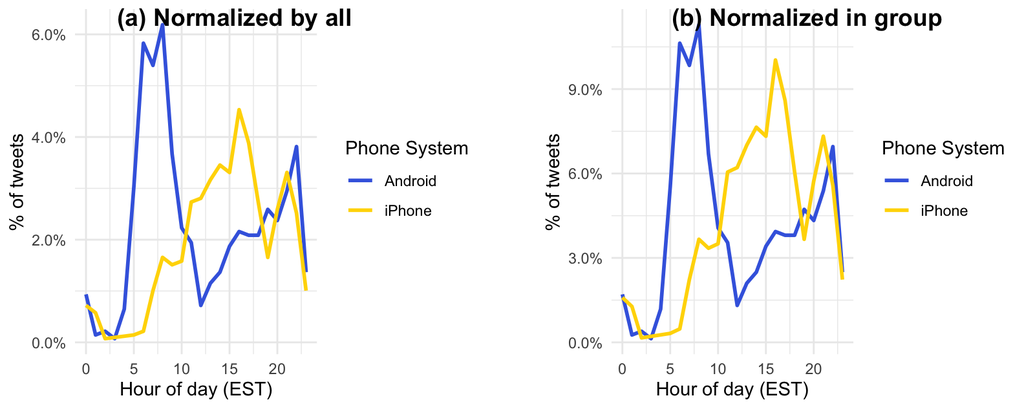

```r
# lubridate::hour()
# lubridate::with_tz()
# scales::percent_format()

toplot1 <- tweets %>%
    count(source, hour = hour(with_tz(created, "EST"))) %>%
    # group_by(source) %>%
    mutate(percent = n / sum(n))
    # ungroup() %>%

toplot2 <- tweets %>%
    count(source, hour = hour(with_tz(created, "EST"))) %>%
    group_by(source) %>%
    mutate(percent = n / sum(n)) %>%
    ungroup()

p1 <- toplot1 %>%
    ggplot() +
    aes(hour, percent, color = source) +
    geom_line(size = 1) +
    scale_color_manual(name = "Phone System",
                       labels = c("Android", "iPhone"),
                       values = c("royalblue", "gold")) +
    scale_y_continuous(labels = percent_format()) +
    labs(x = "Hour of day (EST)",
         y = "% of tweets",
         color = "") + theme_minimal()
p2 <- toplot2 %>%
    ggplot() +
    aes(hour, percent, color = source) +
    geom_line(size = 1) +
    scale_color_manual(name = "Phone System",
                       labels = c("Android", "iPhone"),
                       values = c("royalblue", "gold")) +
    scale_y_continuous(labels = percent_format()) +
    labs(x = "Hour of day (EST)",
         y = "% of tweets",
         color = "") + theme_minimal()

cowplot::plot_grid(
  p1, NULL, p2,
  labels = c("(a) Normalized by all", "", "(b) Normalized in group"), nrow = 1, rel_widths = c(1, 0.1, 1)
)
```

# With Pictures(or not) by phone types

- Filtering out tweets starting with `"` (those tweets mention #realdonaldtrump)
- Mutating new variable `picture` to indicate whether text has picture or not?
- Counting `source` by `picture`
- Plotting bar chart to compare difference between sources.

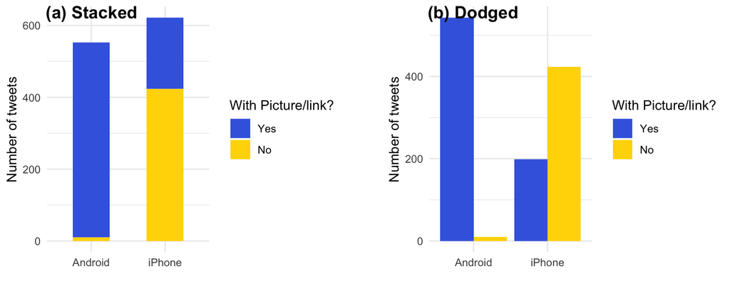

```r
# library(stringr)
toplot <- tweets %>%
    filter(!str_detect(text, '^"')) %>%
    mutate(picture = if_else(str_detect(text, "t.co"),
                             "Picture/link", "No picture/link")) %>%
    count(source, picture)
p1 <- toplot %>%
    ggplot() +
    aes(source, n, fill = picture) +
    geom_col(position="stack", width = 0.5) +
    scale_fill_manual(name = "With Picture/link?",
                      labels = c("Yes", "No"),
                      values = c("royalblue", "gold")) +
    labs(x = "", y = "Number of tweets", fill = "") + theme_minimal()

p2 <- toplot %>%
    ggplot() +
    aes(source, n, fill = picture) +
    geom_col(position="dodge") +
    scale_fill_manual(name = "With Picture/link?",
                      labels = c("Yes", "No"),
                      values = c("royalblue", "gold")) +
    labs(x = "", y = "Number of tweets", fill = "") + theme_minimal()

cowplot::plot_grid(
  p1, NULL, p2,
  labels = c("(a) Stacked", "", "(b) Dodged"), nrow = 1, rel_widths = c(1, 0.1, 1)
)
```

# Comparison of words

```r
library(tidytext)   # unnest_tokens()
library(stringr)    # str_detect(), str_replace_all()

# View(test)

# stop_words$word

tweet_words <- tweets %>%
    filter(!str_detect(text, '^"')) %>%
    mutate(text = str_replace_all(text, "https://t.co/[A-Za-z\\d]+|&amp;", "")) %>%
    # unnest_tokens(word, text) %>%
    # unnest_tokens(word, text, token = "regex", pattern = "[^A-Za-z\\d#@']") %>%
    mutate(word = str_split(text, " ")) %>%
    select(id, text, word, everything()) %>%
    unnest(word) %>%
    filter(!word %in% stop_words$word,
           str_detect(word, "[a-z]"))
# View(tweet_words)
```

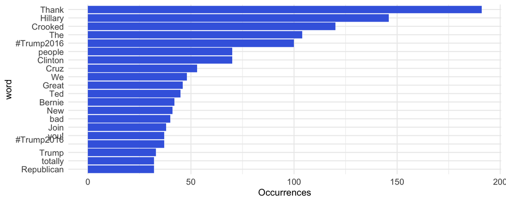

```r
tweet_words %>%
  count(word, sort = TRUE) %>%
  head(20) %>%
  mutate(word = reorder(word, n)) %>%
  ggplot(aes(word, n)) +
  geom_col(fill = "royalblue") +
  ylab("Occurrences") +
  coord_flip() + theme_minimal() +
  theme(axis.text = element_text(size=10))
```

# words frequency by different devices

```r
test <- tweet_words %>%
    count(word, source) %>%
    filter(n >= 5) %>%
    spread(source, n, fill = 0)
# View(test)

word_by_source <- tweet_words %>%
    count(word, source) %>%
    filter(n >= 5) %>%
    spread(source, n, fill = 0) %>%
    ungroup()

sum(word_by_source$iPhone)
```

```
## [1] 1383
```

```r
sum(word_by_source$Android)
```

```
## [1] 2132
```

```r
android_iphone_ratios <- word_by_source %>%
    mutate(iPhone = (iPhone+1)/sum(iPhone+1)) %>%
    mutate(Android = (Android+1)/sum(Android+1)) %>%
    # mutate_at(.cols = vars(iPhone, Android),
    # .funs = funs((. + 1) / sum(. + 1))) %>%
    mutate(logratio = log2(Android / iPhone)) %>%
    arrange(desc(logratio))
```

## visualizing ratio

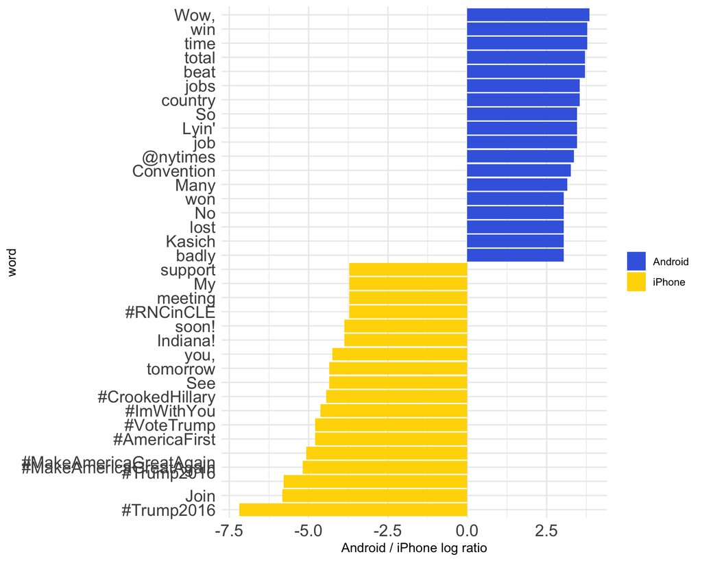

```r
android_iphone_ratios %>%
    group_by(logratio > 0) %>%
    top_n(15, abs(logratio)) %>%
    ungroup() %>%
    mutate(word = reorder(word, logratio)) %>%
    ggplot(aes(word, logratio, fill = logratio < 0)) +
    geom_col() +
    coord_flip() +
    ylab("Android / iPhone log ratio") +
    scale_fill_manual(name = "", labels = c("Android", "iPhone"),
                      values = c("royalblue", "gold")) +
    theme_minimal() +
    theme(axis.text = element_text(size=14))
```